# Mémoire - MAP565 Time series analysis - Analyse de rendement des actifs financiers

Francisco ECKHARDT et Artem NEMCHENKO

Dans ce projet on voudrait analyser les rendements (log returns) et la dépendance des actions des compagnies ENGIE et TOTAL.

# 1 Données

Les données sont les prix de cloture ajustés (*Adjusted Close*) des actions de ENGIE et de TOTAL sur la durée de 5 ans à partir de 01/01/2012 jusqu’au 31/12/2016, elles peuvent être trouvées au travers des liens suivants:

http://finance.yahoo.com/quote/ENGIY/history?period1=1325286000&period2=1483138800&interval=1d&filter=history&frequency=1d http://finance.yahoo.com/quote/TOT/history?period1=1325286000&period2=1483138800&interval=1d&filter=history&frequency=1d

```r
library(ggplot2);theme_set(theme_bw())

engie_url = "http://chart.finance.yahoo.com/table.csv?s=ENGIY&a=11&b=31&c=2011&d=11&e=31&f=2016&g=d&ignore=.csv"
total_url = "http://chart.finance.yahoo.com/table.csv?s=TOT&a=11&b=31&c=2011&d=11&e=31&f=2016&g=d&ignore=.csv"

yahoo.read <- function(url){
   dat <- read.table(url,header=TRUE,sep=",")
   df <- dat[,c(1,7)] # Adj.Close
   df$Date <- as.Date(as.character(df$Date))
   return(df)}

engie <- yahoo.read(engie_url)
total <- yahoo.read(total_url)

library(xts); library(dygraphs)
engie_xts <- xts(engie$Adj.Close,order.by=engie$Date,frequency=365)
total_xts <- xts(total$Adj.Close,order.by=total$Date,frequency=365)

stocks <- cbind(engie_xts,total_xts)

dygraph(stocks,ylab="USD",
        main="Prix de cloture ajustés de ENGIE et TOTAL") %>%
  dySeries("..1",label="engie") %>%
  dySeries("..2",label="total") %>%
  dyOptions(colors = c("blue","brown")) %>%
  dyRangeSelector()
```

[interactive chart not shown]

# 2 Rendement de l’action - log returns

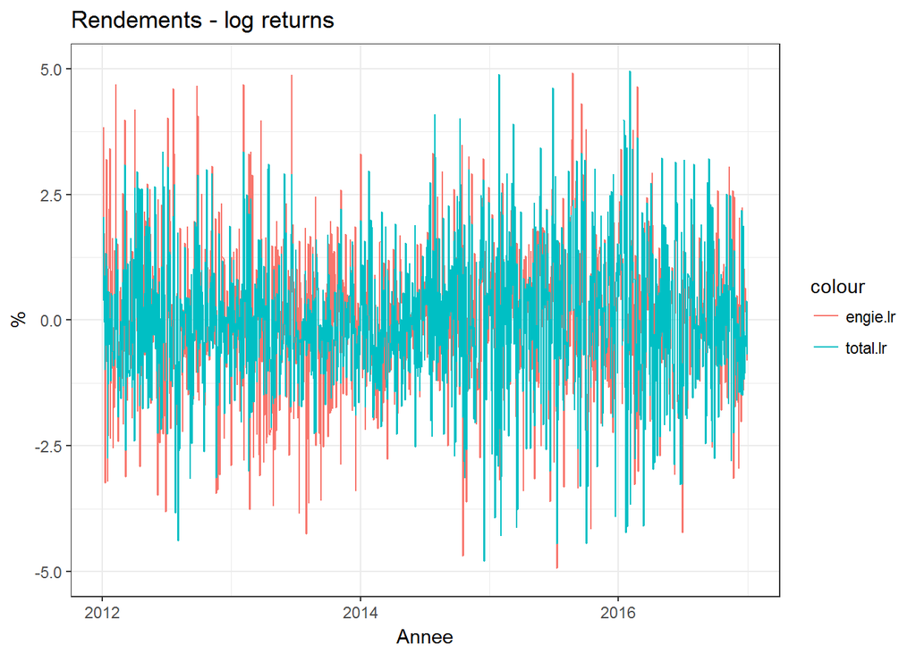

```r
library(zoo); library(PerformanceAnalytics)
engie.zoo = zoo(engie[,-1], order.by=as.Date(strptime(as.character(engie[,1]), "%Y-%m-%d")))
engie.zoo.lr = CalculateReturns(engie.zoo)*100
total.zoo = zoo(total[,-1], order.by=as.Date(strptime(as.character(total[,1]), "%Y-%m-%d")))
total.zoo.lr = CalculateReturns(total.zoo)*100

#Il y a plusieurs façons de calcul de log returns
engie.lr = diff(log(engie$Adj.Close))*100
total.lr = diff(log(total$Adj.Close))*100

ggplot(NULL) +
  geom_line(aes(x=as.Date(engie$Date[1:length(engie.lr)]),y=engie.lr,color="engie.lr"))+
  geom_line(aes(x=as.Date(engie$Date[1:length(engie.lr)]),y=total.lr,color="total.lr"))+ylim(-5,5)+ggtitle("Rendements - log returns")+ xlab("Année")+ ylab("%")
```

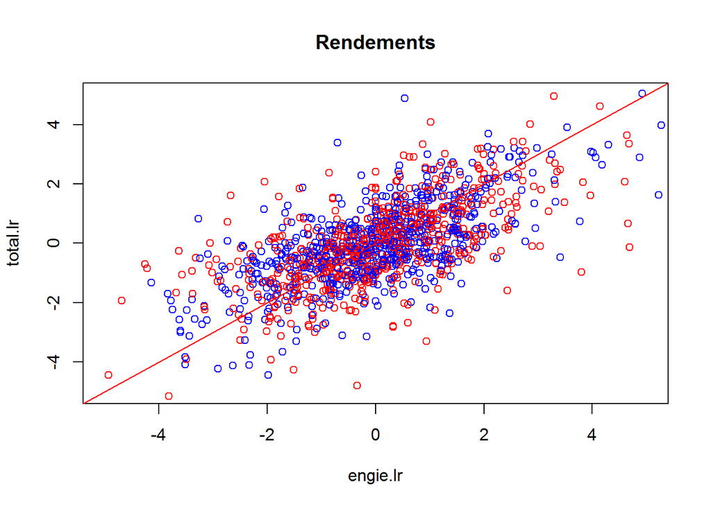

```r
plot(engie.lr,total.lr, xlim=c(-5,5), ylim=c(-5,5),col=c("blue","red"),main="Rendements")
abline(a = 0, b = 1, col = 2)
```

On remarque qu’une dépendance des cours des actions de ENGIE et de cells de TOTAL est bien présente.

## 2.1 Un peu de statistique

```r
summary(engie$Adj.Close)
```

```
##    Min. 1st Qu.  Median    Mean 3rd Qu.    Max.
##   11.87   15.41   17.10   17.46   19.09   24.42
```

```r
summary(total$Adj.Close)
```

```
##    Min. 1st Qu.  Median    Mean 3rd Qu.    Max.
##   31.76   40.46   44.96   45.02   47.98   63.30
```

```r
summary(engie.lr)
```

```
##     Min.  1st Qu.   Median     Mean  3rd Qu.     Max.
## -6.45400 -0.94690  0.00000  0.03478  0.98700 12.28000
```

```r
var(engie.lr)
```

```
## [1] 2.678693
```

```r
summary(total.lr)
```

```
##     Min.  1st Qu.   Median     Mean  3rd Qu.     Max.
## -5.93800 -0.88110 -0.10970 -0.02027  0.80940  9.05100
```

```r
var(total.lr)
```

```
## [1] 2.280586
```

## 2.2 Comparaison avec le processus gaussien des mêmes paramètres

On voit que nos processus ressemblent visuellement le processus gaussien indépendant des mêmes paramètres, mais quand même dans nos données il y a des dépendances intrinsèques - il y a des segments de la grande et de la petite volatilités, elles n’est pas indépendante d’une date à l’autre.

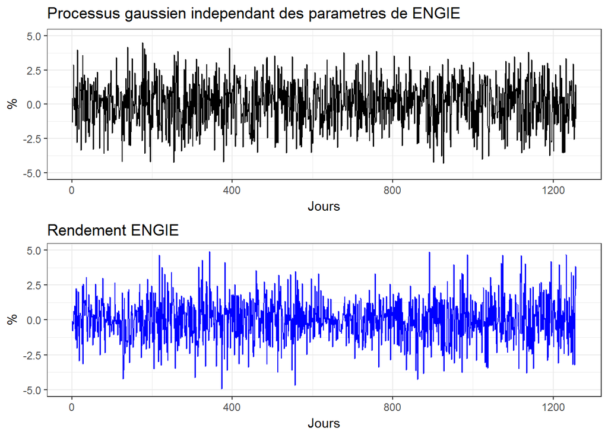

```r
require(MASS); library(gridExtra)
engie.gauss = mvrnorm(n = length(engie.lr), mean(engie.lr), var(engie.lr))
total.gauss = mvrnorm(n = length(total.lr), mean(total.lr), var(total.lr))

pl1 <- ggplot(NULL) +
  geom_line(aes(x=1:length(engie.lr),y=engie.gauss))+ylim(-5,5)+ ggtitle("Processus gaussien indépendant des paramètres de ENGIE")+ ylab("%")+ xlab("Jours")
pl2 <- ggplot(NULL) +
  geom_line(aes(x=1:length(engie.lr),y=engie.lr),color="blue")+ylim(-5,5)+ ggtitle("Rendement ENGIE")+ ylab("%")+ xlab("Jours")
grid.arrange(pl1, pl2)
```

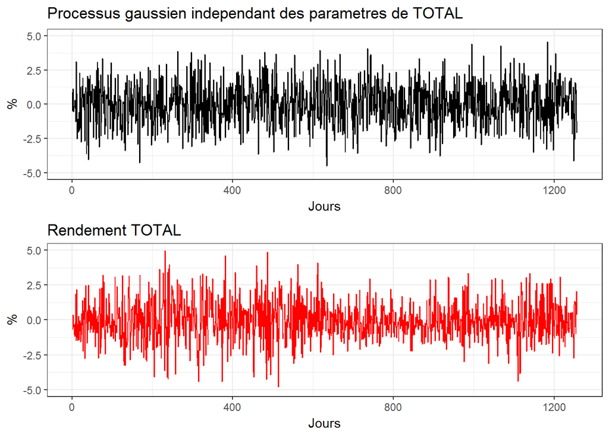

```r
pl1t <- ggplot(NULL) +
  geom_line(aes(x=1:length(total.lr),y=total.gauss))+ylim(-5,5)+ ggtitle("Processus gaussien indépendant des paramètres de TOTAL")+ ylab("%")+ xlab("Jours")
pl2t <- ggplot(NULL) +
  geom_line(aes(x=1:length(total.lr),y=total.lr),color="red")+ylim(-5,5)+ ggtitle("Rendement TOTAL")+ ylab("%")+ xlab("Jours")
grid.arrange(pl1t, pl2t)
```

## 2.3 Méthode ACF pour estimer la fonction d’autocovariance

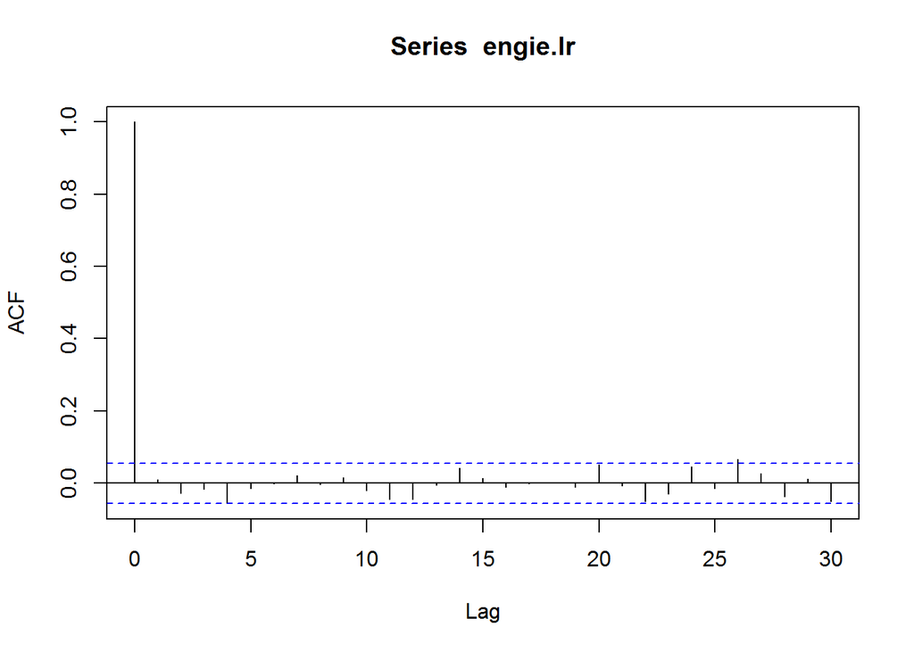

```r
library(stats)
acf(engie.lr, lag.max = NULL,type = c("correlation", "covariance", "partial"),plot = TRUE, na.action = na.fail, demean = TRUE)
```

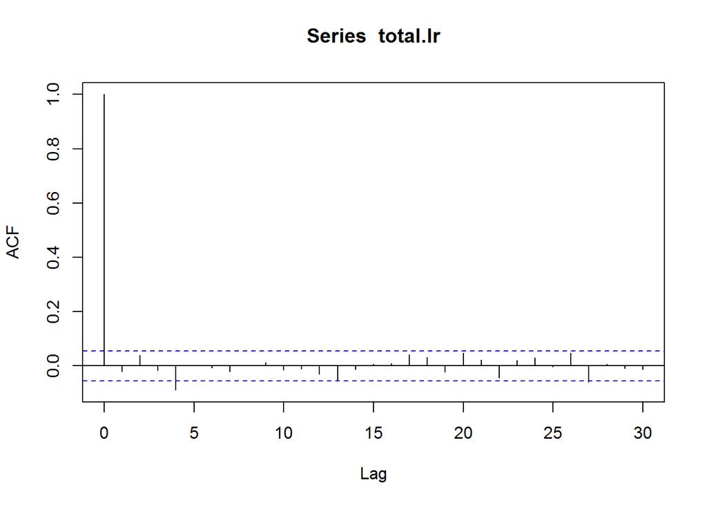

```r
acf(total.lr, lag.max = NULL,type = c("correlation", "covariance", "partial"),plot = TRUE, na.action = na.fail, demean = TRUE)
```

## 2.4 Pour voir d’autres dépendances internes

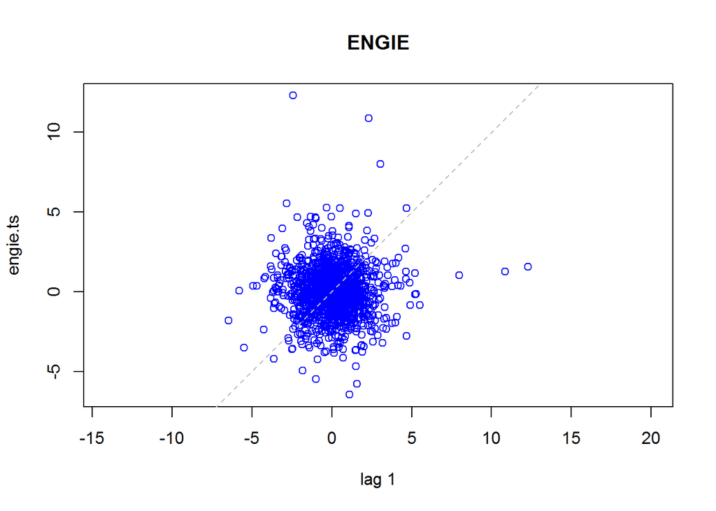

```r
library(tseries)
#engie.ts = ts(engie[,-1], order.by=as.Date(strptime(as.character(engie[,1]), "%Y-%m-%d")))
engie.ts = ts(data=engie.lr, end=c(2016,12,30), start=c(2012,01,3), frequency=365)
total.ts = ts(data=total.lr, end=c(2016,12,30), start=c(2012,01,3), frequency=365)

lag.plot(engie.ts,col=4,main="ENGIE")
```

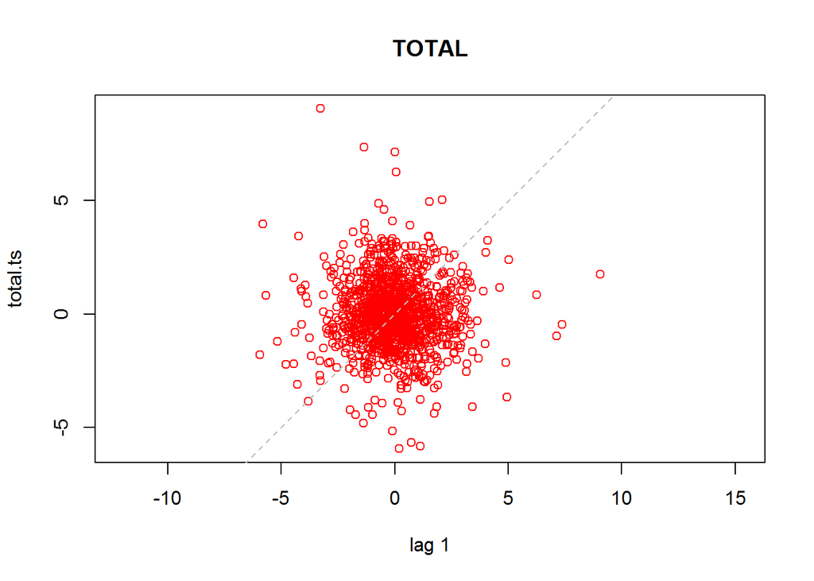

```r
lag.plot(total.ts,col=2,main="TOTAL")
```

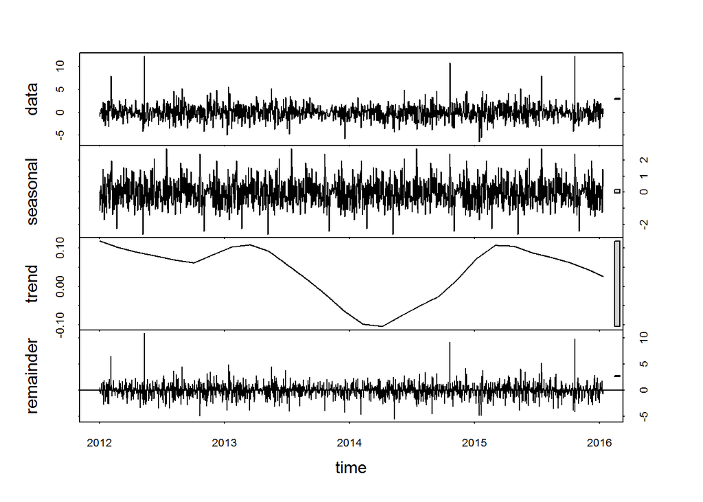

```r
engie.decompose = stl(engie.ts, s.window = "periodic")
plot(engie.decompose)
```

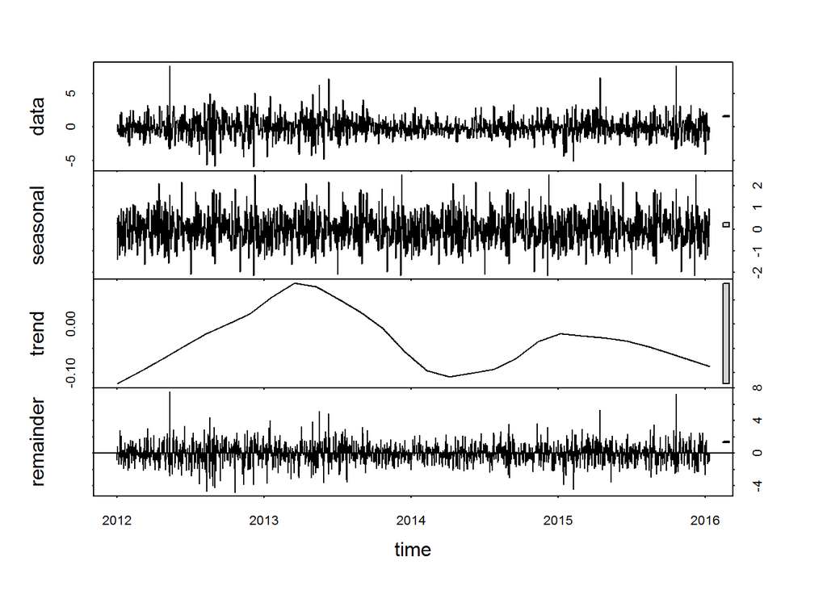

```r
total.decompose = stl(total.ts, s.window = "periodic")
plot(total.decompose)
```

```r
Box.test(engie.ts, lag = 1, type = "Ljung-Box")
```

```
##
##  Box-Ljung test
##
## data:  engie.ts
## X-squared = 1.2918, df = 1, p-value = 0.2557
```

```r
Box.test(total.ts, lag = 1, type = "Ljung-Box")
```

```
##
##  Box-Ljung test
##
## data:  total.ts
## X-squared = 0.58292, df = 1, p-value = 0.4452
```

Si la p-value du test de Ljung-Box est plus grands que 0.05 (5%), alors on préfère de ne pas rejeter l’hypothèse nulle qui dit que la série temporelle considérée est indépendante. Pour ENGIE et pour TOTAL on obtenient les p-valeurs bien plus grandes que 0.05, alors on suppose que les séries sont indépendantes (les moments du temps de chaque série sont indépendants).

Mais ce résultat n’est pas en accord avec nos observations précédantes. Alors, regardons ce que nous donnent des madèles de régression suivants.

# 3 Modèles AR et GARCH

```r
engie.ar$order
```

```
## [1] 4
```

```r
total.ar$order
```

```
## [1] 4
```

```r
engie.garch$order
```

```
## p q
## 1 1
```

```r
engie.garch$coef
```

```
##        a0        a1        b1
## 0.3768487 0.1151214 0.7542969
```

```r
total.garch$order
```

```
## p q
## 1 1
```

```r
total.garch$coef
```

```
##         a0         a1         b1
## 0.09102596 0.10609179 0.85889173
```

Ainsi, nos séries peuvent être décrites par AR(4) et par GARCH(1,1), alors il y a une sorte de dépendance interne.

## 3.1 Un petit peu de prédiction

On essaie d’approximer les données par le modèle *ARIMA*, mais il n’est pas convenable dans ce cas, car deux paramètres sont nuls - on obtient `ARIMA(0,1,0)`, $p=q=0$

```r
library(forecast)
engie.ts.lr = ts(engie[1:500,],frequency = 7)
y=auto.arima(engie.ts.lr[,"Adj.Close"])
y
```

```
## Series: engie.ts.lr[, "Adj.Close"]
## ARIMA(0,1,0) with drift
##
## Coefficients:
##        drift
##       0.0132
## s.e.  0.0117
##
## sigma^2 estimated as 0.06884:  log likelihood=-39.91
## AIC=83.82   AICc=83.84   BIC=92.24
```

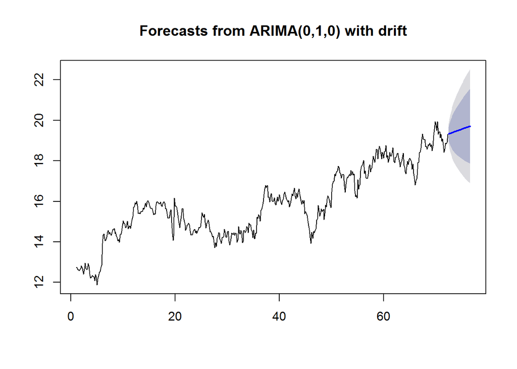

```r
plot(forecast(y,h=30))
```

```r
y=auto.arima(ts(engie.zoo.lr[1100:1200],freq = 7))
y
```

```
## Series: ts(engie.zoo.lr[1100:1200], freq = 7)
## ARIMA(2,0,2)(0,0,1)[7] with zero mean
##
## Coefficients:
##          ar1      ar2      ma1     ma2     sma1
##       1.4090  -0.9328  -1.3838  0.7842  -0.2571
## s.e.  0.0659   0.0535   0.1262  0.1193   0.0918
##
## sigma^2 estimated as 2.574:  log likelihood=-189.13
## AIC=390.27   AICc=391.16   BIC=405.96
```

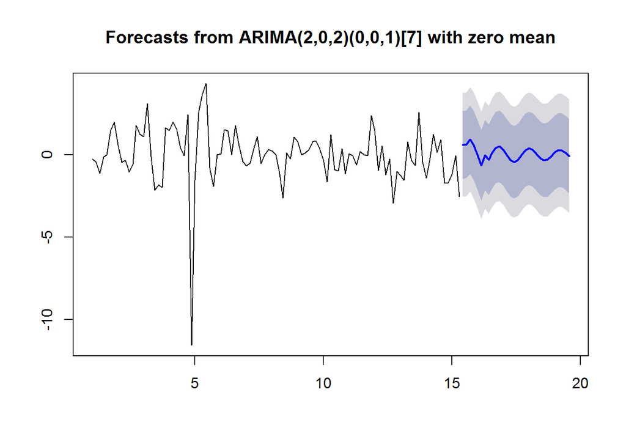

```r
plot(forecast(y,h=30))
```

## 3.2 Corrélation empirique entre les séries (entre les rendements de ENGIE et TOTAL)

```r
corr.e = (mean(engie.lr*total.lr)-mean(engie.lr)*mean(total.lr))/sd(engie.lr)/sd(total.lr)
print(corr.e)
```

```
## [1] 0.6317064
```

# 4 Fonctions de répartition empirique

$$\hat F_n(t) = \frac{ \mbox{number of elements in the sample} \leq t}n = \frac{1}{n} \sum_{i=1}^n \mathbf{1}(X_i\leq x)$$

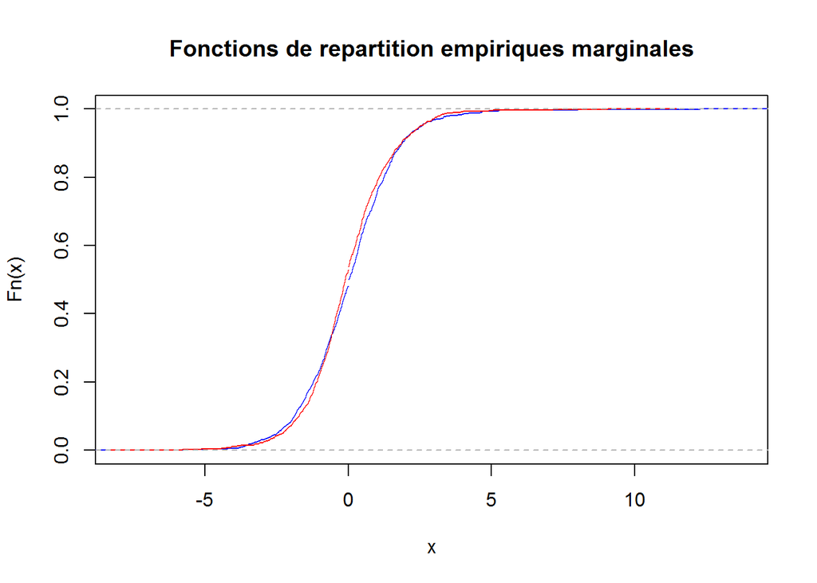

```r
library(graphics); library(scatterplot3d)
engie.Fn <- ecdf(engie.lr)
total.Fn <- ecdf(total.lr)
plot(engie.Fn,col="blue",main="Fonctions de répartition empiriques marginales")
lines(total.Fn,col="red")
```

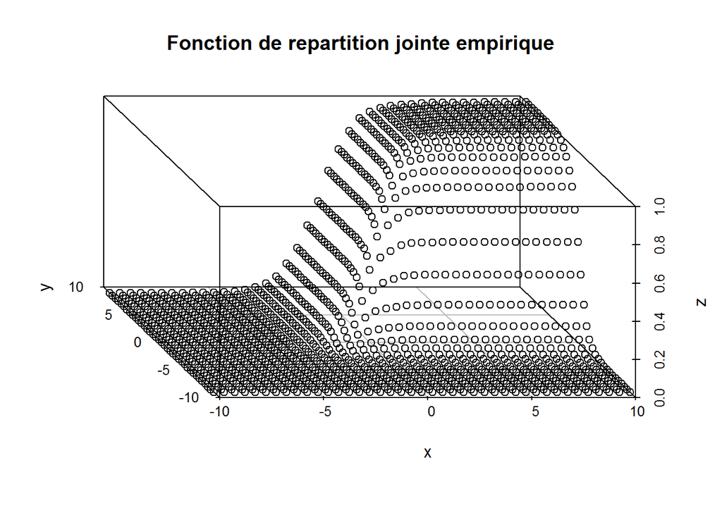

```r
Fn2 = function(x,y,X,Y){
  z = 0
  #X = engie.lr; Y = total.lr
  l = length(X)
  if (length(X)!=length(Y)){
    print("Problem : length(X)!=length(Y)")
  }
  for (i in 1:l){
    if ((X[i]<x)&(Y[i]<y)){
      z = z+1
    }
  }
  z = z/l
  return(z)
}

PreptoPlot = function(x,y,X,Y,copule.b =  FALSE){
  xx = 0
  yy = 0
  zz = 0
  for (i in x){
    for (j in y){
      xx = c(xx,i)
      yy = c(yy,j)
      if (copule.b){
        zz = c(zz,copule(i,j,X,Y))
      }else{
        zz = c(zz,Fn2(i,j,X,Y))
      }
    }
  }
  xx = xx[-1]
  yy = yy[-1]
  zz = zz[-1]
  z = data.frame(xx,yy,zz)
  return(z)
}

x = seq(from = -10, to =  10, by = 0.5); y = seq(from = -9,  to =  9,  by = 0.5)
toPlot = PreptoPlot(x,y,engie.lr,total.lr)
scatterplot3d(x = toPlot$xx, y = toPlot$yy, z = toPlot$zz, angle = 115, main="Fonction de répartition jointe empirique", xlab = "x", ylab = "y", zlab = "z")
```

Les fonctions de répartitions marginales sont presque les mêmes.

## 4.1 Plot 3D

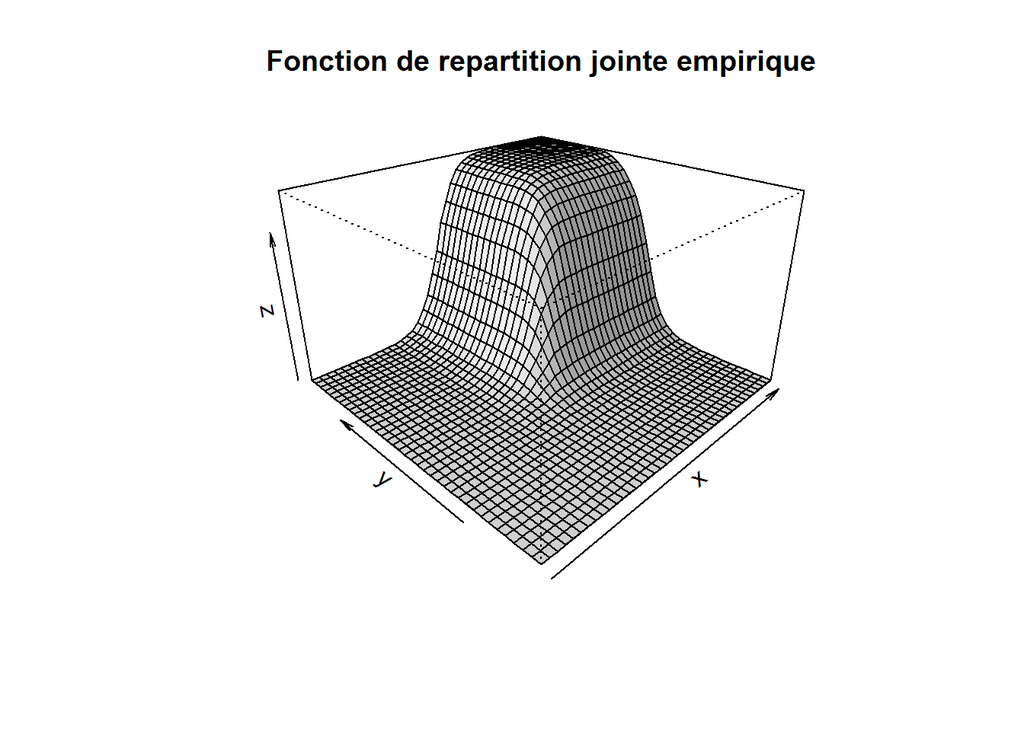

```r
PreptoPlot3d = function(x,y,X,Y,copule.b = FALSE){
  lx = length(x)
  ly = length(y)
  m = matrix(0,lx,ly)
  for (i in 1:lx){
    for (j in 1:ly){
      if (copule.b){
        m[i,j] = copule(x[i],y[j],X,Y)
      }else{
        m[i,j] = Fn2(x[i],y[j],X,Y)
      }
    }
  }
  return(m)
}

z = PreptoPlot3d(x,y,engie.lr,total.lr)
persp(x=x, y=y, z=z, theta=-45, phi=25, expand=0.6, shade=0.3,main="Fonction de répartition jointe empirique")
```

# 5 Copule

## 5.1 Rank empirique

$$R_k^i=\sum_{j=1}^n \mathbf{1}(X_k^j\leq X_k^i)$$

```r
Rank = function(set,point){
  set = sort(set)
  r = which.max(set[set<point])
  if (length(r)==0) r = 0
  return(r)
}
Rank(engie.lr, -1)
```

```
## [1] 295
```

```r
Rank(engie.lr, 101)
```

```
## [1] 1257
```

```r
Rank(total.lr, 101)
```

```
## [1] 1257
```

## 5.2 Copule empirique

$$C^n(u_1,\dots,u_d) = \frac{1}{n} \sum_{i=1}^n \mathbf{1}\left(\tilde{U}_1^i\leq u_1,\dots,\tilde{U}_d^i\leq u_d\right)$$
où
$$\tilde{U}_k^i=R_k^i/n$$
Dans notre cas où on cherche à estimer la dépendance de deux actifs, la dimension $d=2$.

```r
copule = function(u,v,X,Y){
  if (length(X)!=length(Y))
    print("Problem : length(X)!=length(Y)")
  l = length(X)
  rank.x = 1:l
  rank.y = 1:l
  for (i in 1:l){
    rank.x[i] = Rank(X,X[i])
    rank.y[i] = Rank(Y,Y[i])
  }
  return(Fn2(u,v,rank.x/l,rank.y/l))
}

copule(0.9,1,engie.lr,total.lr)
```

```
## [1] 0.9005569
```

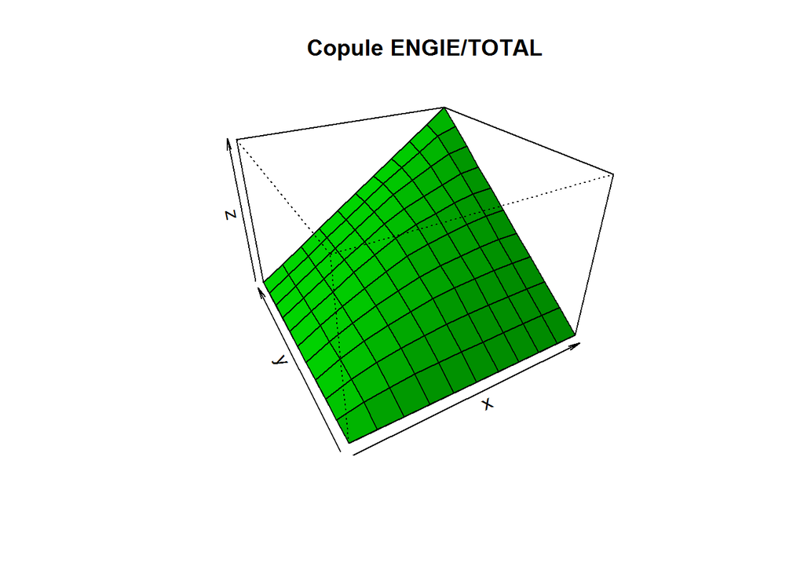

```r
xc = seq(from = 0, to =  1, by = 0.1); yc = seq(from = 0, to =  1, by = 0.1)
zc = PreptoPlot3d(xc,yc,engie.lr,total.lr, copule.b=TRUE)
persp(x=xc, y=yc, z=zc, theta=-30, phi=30, expand=0.7, shade=0.5, main="Copule ENGIE/TOTAL", col="green", xlab="x", ylab="y", zlab="z")
```

```r
# toPlot.c = PreptoPlot(xc,yc,engie.lr,total.lr, copule.b=TRUE) # prend beaucoup de temps car n'est pas optimisé
# scatterplot3d(x = toPlot.c$xx, y = toPlot.c$yy, z = toPlot.c$zz, angle = 115)
```

La copule est bien une copule gaussienne.

# 6 Le rho de Spearman

```r
rho = function(X,Y){
  if (length(X)!=length(Y))
    print("Problem : length(X)!=length(Y)")
  l = length(X)
  rho = 0
  for (i in 1:l){
    for (j in 1:l){
      rho = rho + copule(i/l,j/l,X,Y) - i*j/l^2
    }
  }
  return(rho*12/(l^2-1))
}

#start.time = Sys.time()
N = 100
rho.e = rho(engie.lr[1:N],total.lr[1:N])
#end.time = Sys.time()
#time.taken = end.time - start.time
print(rho.e)
```

```
## [1] 0.4910531
```

```r
#time.taken
```

# 7 Partie de test - pour vérifier les paramètres du copule

Dans cette partie on voudrait comparer nos valeurs de la corrélation et du rho de Spearman avec ceux obtenus par des méthodes existantes optimisées.

## 7.1 Corrélation

```r
library(psych)
e.t = cbind(engie.lr,total.lr)
cor(e.t)
```

```
##           engie.lr  total.lr
## engie.lr 1.0000000 0.6322094
## total.lr 0.6322094 1.0000000
```

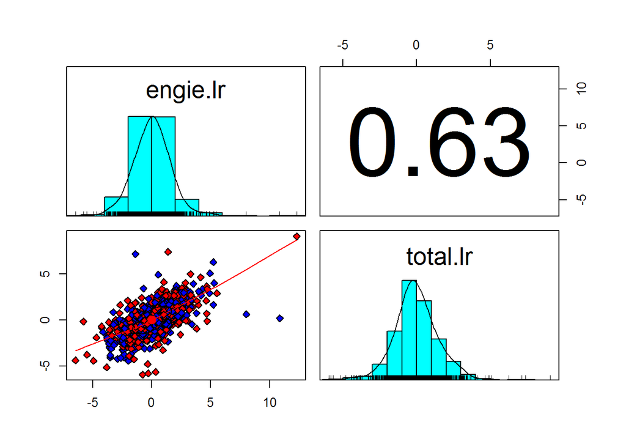

```r
pairs.panels(e.t, pch = 23, bg =c("blue","red"))
```

## 7.2 Rho de Spearman

```r
mat = matrix(0, 100,2)
for(i in 1:100){
    mat[i,1] = engie.lr[i]
    mat[i,2] = total.lr[i]
}

# Normal copula
library(copula)
normal.cop = normalCopula(dim=2)
fit.cop = fitCopula(normal.cop,pobs(mat),method="ml")

# Coefficients
rho = coef(fit.cop)
print(rho)
```

```
##     rho.1
## 0.5270655
```

# 8 Conclusion

1. Le rendement (log return) de ENGIE et ceux de TOTAL sont des bruits blancs faibles.
2. L’hypothèse de l’indépendance intrinsèque de chaque de ces deux séries temporelles n’est pas par le teste Ljung-Box.
3. Puis, chaque de deux séries peut être modélisée par AR(4) ou GARCH(1,1), alors il y a une sorte de la dépendance interne dans chaque série de rendements.
4. La corrélation entre ces deux séries est `0.63`.
5. Le rho de Spearman (décrit la dépendance entre deux séries) est `0.53`, le résultat “empirique” (estimé par une fonction créée par nous-mêmes) converge vers cette valeur-là (en etant pas optimisé notre petit algorithme calcule plusierus fois les mêmes choses et prend beaucoup de temps).
6. Les fonction de répartitions marginales empiriques de ENGIE et de TOTAL se ressemblent bien.
7. La copule empirique ressemble bien celle gaussienne.

Alors, les séries de rendement dépendent bien l’une de l’autre, ainsi qu’il y a la dépendance interne “faible” (les log returns sont des bruits blancs faibles)